# Compare velocity values from Bioshifts v1 and v3

Brunno Oliveira

30 April, 2024

# 1 Setup

```r
library(data.table)
library(dplyr)
library(ggplot2)
library(tidyverse)
library(here)

# set computer
computer = "personal"

source(here("R/settings.R"))
```

# 2 Load in v3 velocities

```r
SA_got <- list.files(here::here("Data/Velocity_SA"), full.names = TRUE, pattern = ".csv")
SA_got <- lapply(1:length(SA_got), function(i) {
  read.csv(SA_got[i])
})


SA_got <- rbindlist(SA_got, fill = TRUE)

SA_got <- SA_got %>%
  dplyr::select(c(v.lat.median.mat,v.lat.mean.mat,
                  baseline.mat,trend.mean.mat,
                  v.ele.median.mat,v.ele.mean.mat,
                  baseline.sst,trend.mean.sst,
                  v.lat.median.sst,v.lat.mean.sst,ID))
names(SA_got)[1:10] <- paste0(names(SA_got)[1:10],".v3")

# v <- rast(here("Data/Velocity_SA/A88_P1_mat_gVel.tif"))
# v.lat <- rast(here("Data/Velocity_SA/A88_P1_mat_gVelLat.tif"))
#
# plot(v)
# plot(v.lat)
# global(v,median,na.rm = TRUE)
# global(v.lat,median,na.rm = TRUE)
```

# 3 Load in Bioshifts v1

```r
Bioshifts_DB <- read.csv(here::here(Bioshifts_dir,Bioshifts_DB_v1))

# Filter Polygons in Study areas v3
Bioshifts_DB <- Bioshifts_DB[Bioshifts_DB$ID %in% unique(SA_got$ID),]

# convert everything to km/year
Bioshifts_DB <- Bioshifts_DB %>%
  mutate(
    Type = case_when(
      Type=="HOR" ~ "LAT",
      TRUE ~ as.character(Type)),
    # Standardize shift measures to km/year
    SHIFT = case_when(
      UNIT == "m/year" ~ SHIFT/1000,
      UNIT == "km/year" ~ SHIFT,
      TRUE ~ NA_real_)) %>%
  filter(Type %in% c("LAT","ELE"))
```

# 4 Merge v1 to v3

```r
Bioshifts_vel <- merge(Bioshifts_DB,
                       SA_got,
                       by = "ID",
                       all.x = TRUE)

Bioshifts_vel <- Bioshifts_vel %>%
  mutate(vel_v1 = ifelse(Type == "LAT", v.lat.mean, v.ele.mean),
         vel_v3 = ifelse(Type == "LAT" & ECO == "T", v.lat.median.mat.v3,
                         ifelse(Type == "ELE" & ECO == "T", v.ele.median.mat.v3, v.lat.median.sst.v3)),
         baseline.temp_v1 = baseline.temp,
         baseline.temp_v3 = ifelse(ECO == "T", baseline.mat.v3, baseline.sst.v3),
         trend_v1 = trend.mean,
         trend_v3 = ifelse(ECO == "T", trend.mean.mat.v3, trend.mean.sst.v3)) %>%
  dplyr::select(ID, Type, ECO, SHIFT,
                baseline.temp_v1, trend_v1, vel_v1,
                baseline.temp_v3, trend_v3, vel_v3,
                DUR, START, END)
```

# 5 Compare

## 5.1 Density plots of velocities

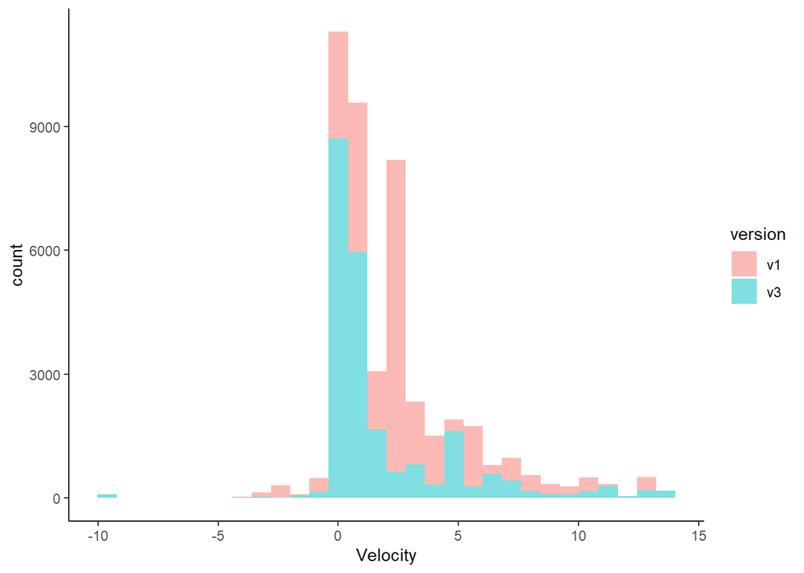

```r
v1 <- Bioshifts_vel[,c("ID","Type","ECO","vel_v1","baseline.temp_v1","SHIFT")]
v3 <- Bioshifts_vel[,c("ID","Type","ECO","vel_v3","baseline.temp_v3","SHIFT")]

v1$baseline.temp <- v1$baseline.temp_v1
v1$vel <- v1$vel_v1
v1$version = "v1"

v3$baseline.temp <- v3$baseline.temp_v3
v3$vel <- v3$vel_v3
v3$version = "v3"

tmp <- rbind(v1[,c("ID","Type","ECO","vel","baseline.temp","SHIFT","version")],
             v3[,c("ID","Type","ECO","vel","baseline.temp","SHIFT","version")])

# All values
ggplot(tmp, aes(x = vel, fill = version))+
  geom_histogram(alpha = .5)+
  theme_classic()+
  labs(x = "Velocity")
```

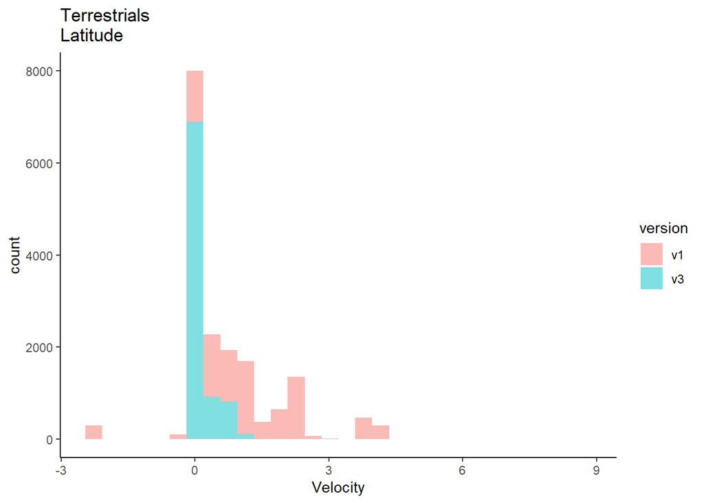

```r
## Terrestrials
### Latitude
ggplot(tmp %>% filter(ECO=="T",
                      Type == "LAT"),
       aes(x = vel, fill = version))+
  ggtitle("Terrestrials\nLatitude")+
  geom_histogram(alpha = .5)+
  theme_classic()+
  labs(x = "Velocity")
```

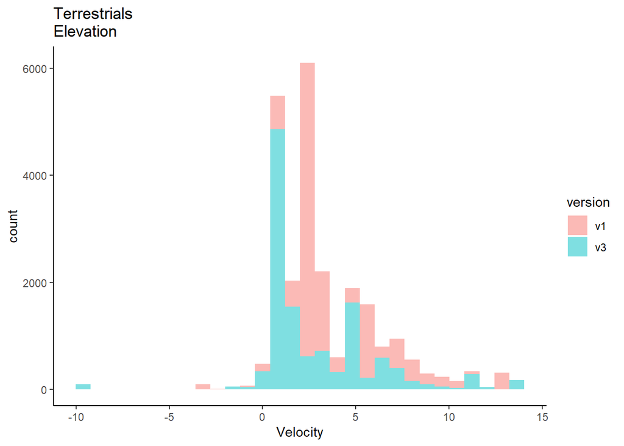

```r
### Elevation
ggplot(tmp %>% filter(ECO=="T",
                      Type == "ELE"),
       aes(x = vel, fill = version))+
  ggtitle("Terrestrials\nElevation")+
  geom_histogram(alpha = .5)+
  theme_classic()+
  labs(x = "Velocity")
```

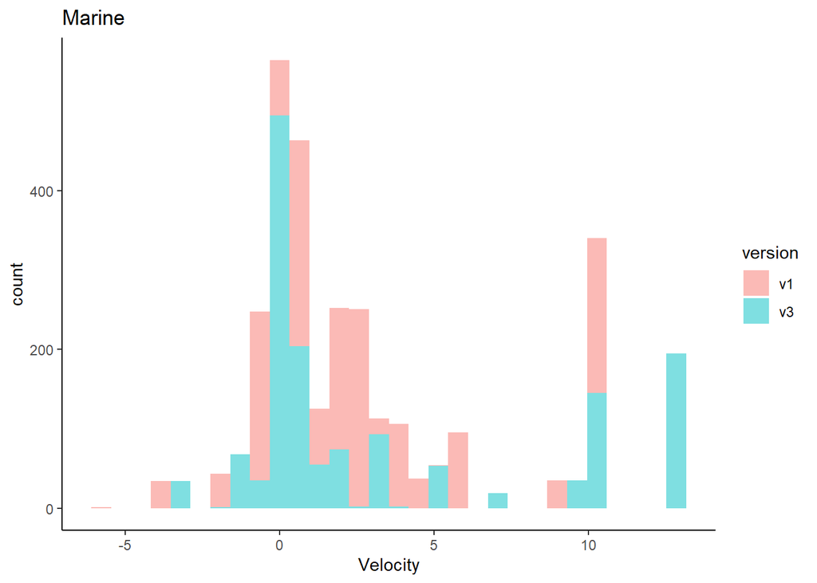

```r
## Marine
ggplot(tmp %>% filter(ECO=="M"),
       aes(x = vel, fill = version))+
  ggtitle("Marine")+
  geom_histogram(alpha = .5)+
  theme_classic()+
  labs(x = "Velocity")
```

## 5.2 Velocity scatter plots

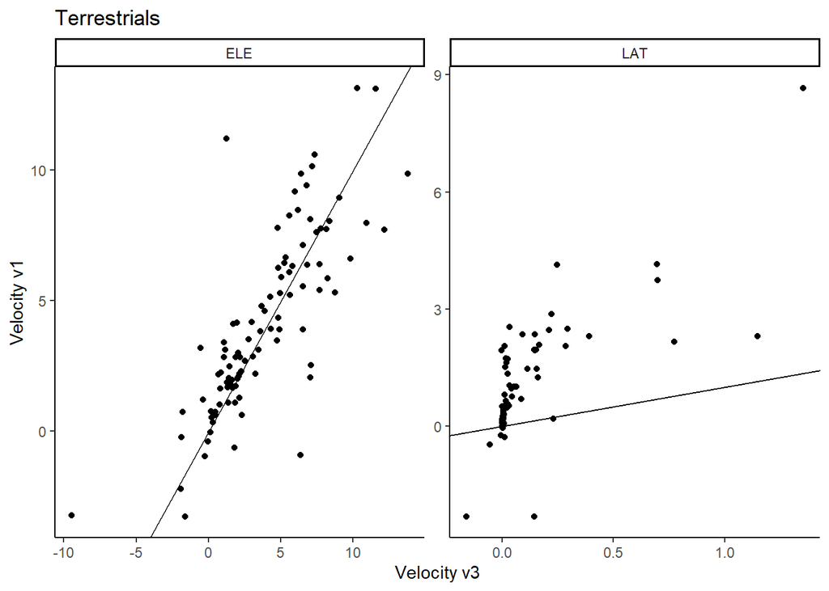

```r
# Terrestrial
ggplot(Bioshifts_vel %>% filter(ECO == "T"),
       aes(x = vel_v3, y = vel_v1)) +
  ggtitle("Terrestrials") +
  geom_point()+
  theme_classic()+
  facet_wrap(.~Type, scales = "free") +
  labs(x = "Velocity v3", y = "Velocity v1")+
  geom_abline(slope = 1, intercept = 0)
```

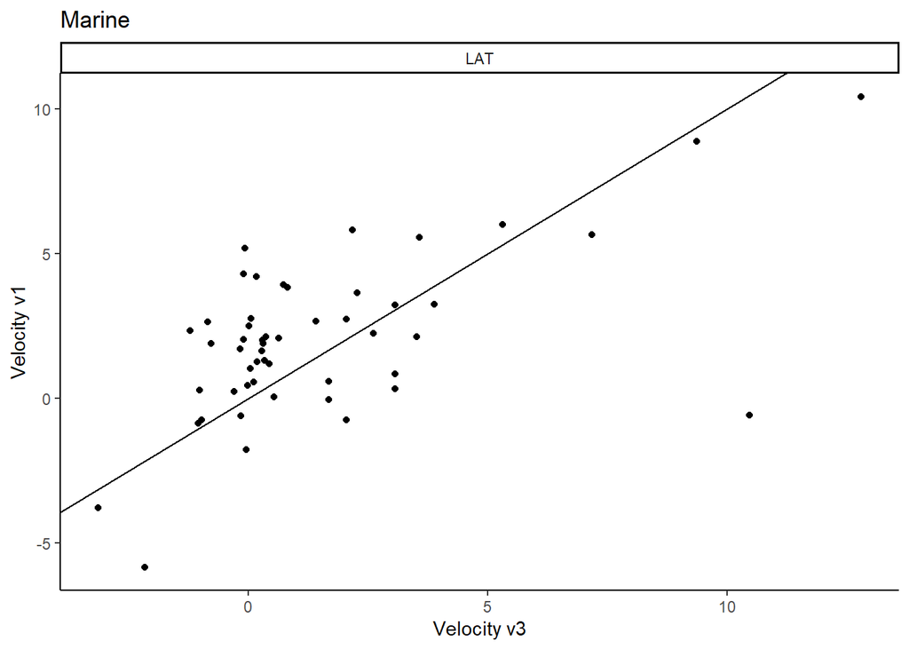

```r
# Marine
ggplot(Bioshifts_vel %>% filter(ECO == "M"),
       aes(x = vel_v3, y = vel_v1)) +
  ggtitle("Marine") +
  geom_point()+
  theme_classic()+
  facet_wrap(.~Type, scales = "free") +
  labs(x = "Velocity v3", y = "Velocity v1")+
  geom_abline(slope = 1, intercept = 0)
```

Velocities are highly correlated for elevation. Latitudinal velocities are not so correlated in both terrestrial and marine environments. The magnitude of terrestrial velocities are much smaller (~10x) than in v3 then v1.

## 5.3 Baseline temperature

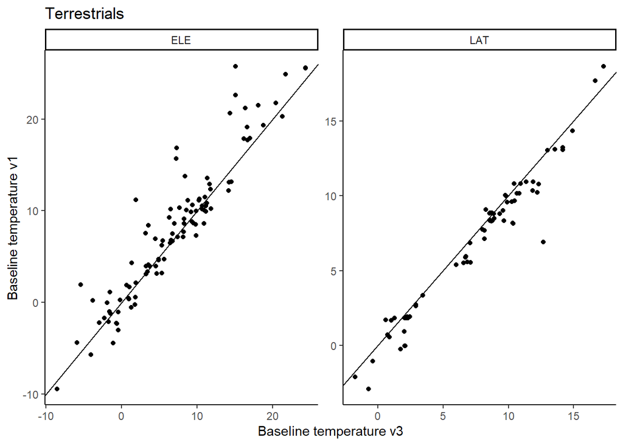

```r
# Terrestrial
ggplot(Bioshifts_vel %>% filter(ECO == "T"),
       aes(x = baseline.temp_v3, y = baseline.temp_v1)) +
  ggtitle("Terrestrials") +
  geom_point()+
  theme_classic()+
  facet_wrap(.~Type, scales = "free") +
  labs(x = "Baseline temperature v3", y = "Baseline temperature v1")+
  geom_abline(slope = 1, intercept = 0)
```

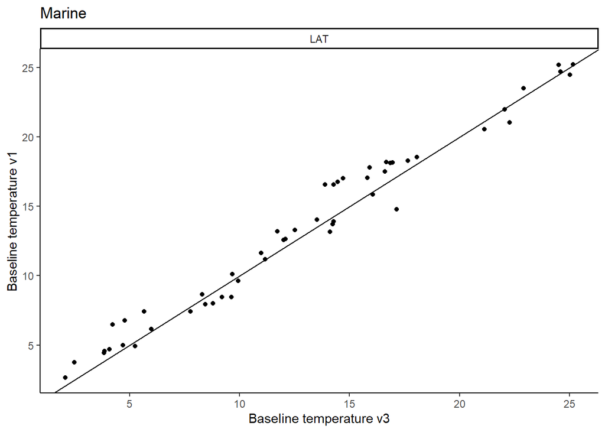

```r
# Marine
ggplot(Bioshifts_vel %>% filter(ECO == "M"),
       aes(x = baseline.temp_v3, y = baseline.temp_v1)) +
  ggtitle("Marine") +
  geom_point()+
  theme_classic()+
  facet_wrap(.~Type, scales = "free") +
  labs(x = "Baseline temperature v3", y = "Baseline temperature v1")+
  geom_abline(slope = 1, intercept = 0)
```

Baseline temperatures are highly similar.

## 5.4 Trend

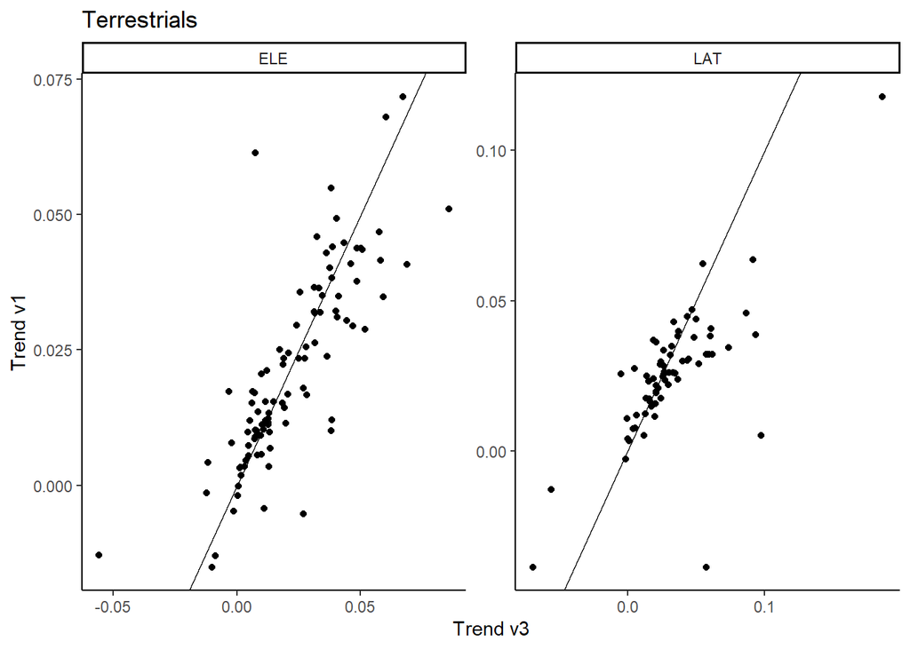

```r
# Terrestrial
ggplot(Bioshifts_vel %>% filter(ECO == "T"),
       aes(x = trend_v3, y = trend_v1)) +
  ggtitle("Terrestrials") +
  geom_point()+
  theme_classic()+
  facet_wrap(.~Type, scales = "free") +
  labs(x = "Trend v3", y = "Trend v1") +
  geom_abline(slope = 1, intercept = 0)
```

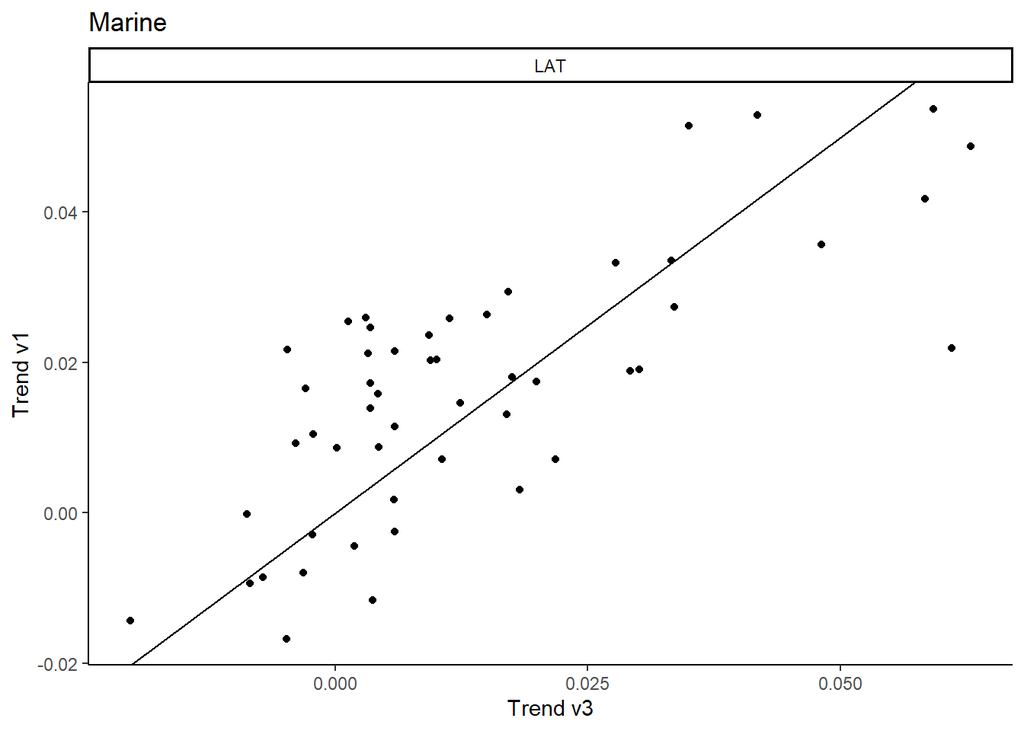

```r
# Marine
ggplot(Bioshifts_vel %>% filter(ECO == "M"),
       aes(x = trend_v3, y = trend_v1)) +
  ggtitle("Marine") +
  geom_point()+
  theme_classic()+
  facet_wrap(.~Type, scales = "free") +
  labs(x = "Trend v3", y = "Trend v1") +
  geom_abline(slope = 1, intercept = 0)
```

Trend is very similar!

If trend and baseline temperatures are very similar, this means that difference in velocities from v1 and v3 can be due to differences in the way the gradient component was calculated. In v1, the gradient was calculated using the fixed climatology from Worldclim. Test if the difference between velocities from v1 and v3 can be explained by duration of the study.

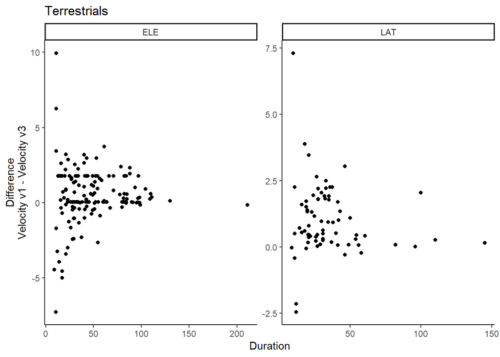

```r
# Terrestrial
ggplot(Bioshifts_vel %>% filter(ECO == "T"),
       aes(x = DUR, y = vel_v1-vel_v3)) +
  ggtitle("Terrestrials") +
  geom_point()+
  theme_classic()+
  facet_wrap(.~Type, scales = "free") +
  labs(x = "Duration", y = "Difference\nVelocity v1 - Velocity v3")
```

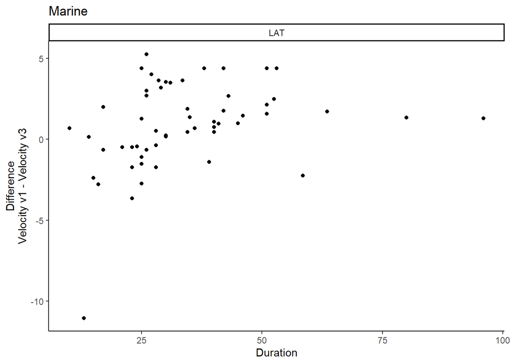

```r
# Marine
ggplot(Bioshifts_vel %>% filter(ECO == "M"),
       aes(x = DUR, y = vel_v1-vel_v3)) +
  ggtitle("Marine") +
  geom_point()+
  theme_classic()+
  facet_wrap(.~Type, scales = "free") +
  labs(x = "Duration", y = "Difference\nVelocity v1 - Velocity v3")
```

## 5.5 Velocity vs shift

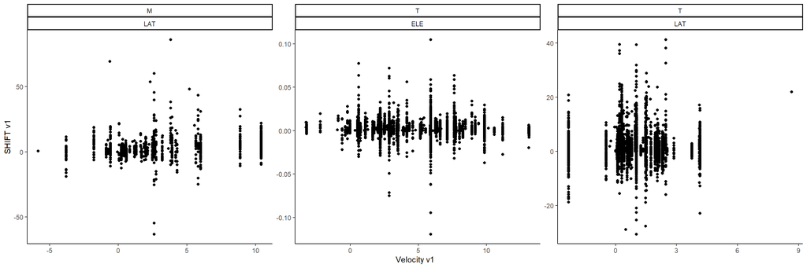

```r
# Velocity v1 vs Shift
ggplot(Bioshifts_vel,
       aes(x = vel_v1, y = SHIFT)) +
  geom_point()+
  theme_classic()+
  facet_wrap(ECO~Type, scales = "free") +
  labs(x = "Velocity v1", y = "SHIFT v1")
```

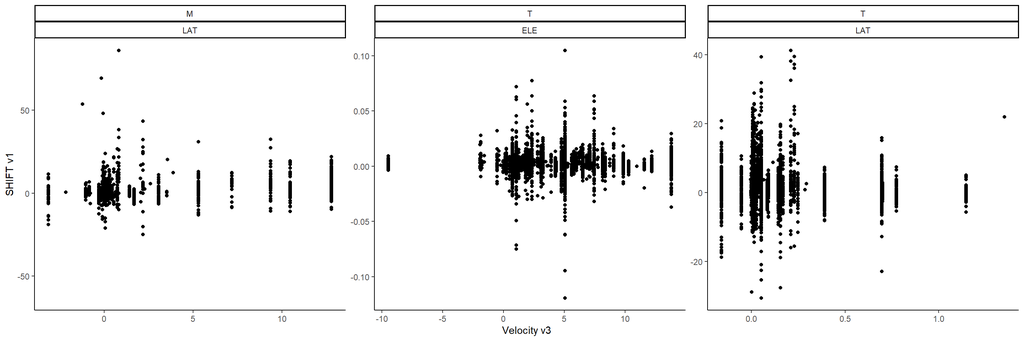

```r
# Velocity v3 vs Shift
ggplot(Bioshifts_vel,
       aes(x = vel_v3, y = SHIFT)) +
  geom_point()+
  theme_classic()+
  facet_wrap(ECO~Type, scales = "free") +
  labs(x = "Velocity v3", y = "SHIFT v1")
```

As expected based on the decoupling between velocity values in v1 and v3, the effect of velocity on observed range shift can be quite different depending on version of bioshifts used to extract velocity values.

## 5.6 OLS results: Velocity vs Shift

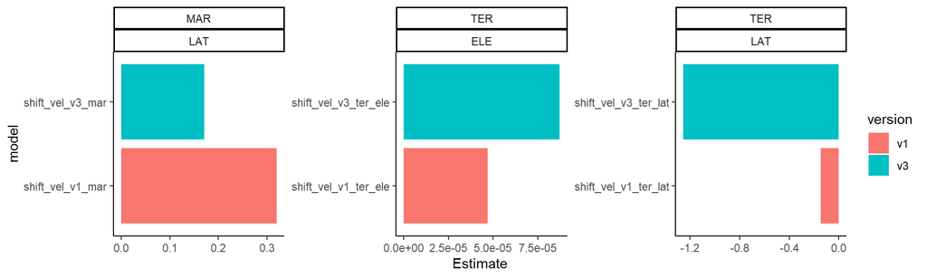

```r
# Terrestrial + Lat
shift_vel_v1_ter_lat <- summary(lm(SHIFT~vel_v1,
                                   Bioshifts_vel %>%
                                     filter(ECO=="T" & Type == "LAT")))

shift_vel_v3_ter_lat <- summary(lm(SHIFT~vel_v3,
                                   Bioshifts_vel %>%
                                     filter(ECO=="T" & Type == "LAT")))

# Terrestrial + Ele
shift_vel_v1_ter_ele <- summary(lm(SHIFT~vel_v1,
                                   Bioshifts_vel %>%
                                     filter(ECO=="T" & Type == "ELE")))

shift_vel_v3_ter_ele <- summary(lm(SHIFT~vel_v3,
                                   Bioshifts_vel %>%
                                     filter(ECO=="T" & Type == "ELE" & !is.infinite(vel_v3))))

# Marine
shift_vel_v1_mar <- summary(lm(SHIFT~vel_v1,
                               Bioshifts_vel %>%
                                 filter(ECO=="M")))

shift_vel_v3_mar <- summary(lm(SHIFT~vel_v3,
                               Bioshifts_vel %>%
                                 filter(ECO=="M")))

models <- list(
  shift_vel_v1_ter_lat,
  shift_vel_v3_ter_lat,
  shift_vel_v1_ter_ele,
  shift_vel_v3_ter_ele,
  shift_vel_v1_mar,
  shift_vel_v3_mar
)
names(models) <- c("shift_vel_v1_ter_lat",
                   "shift_vel_v3_ter_lat",
                   "shift_vel_v1_ter_ele",
                   "shift_vel_v3_ter_ele",
                   "shift_vel_v1_mar",
                   "shift_vel_v3_mar")

Coeffs <- lapply(models, function(x){
  data.frame(x$coefficients)[2,]
})
Coeffs <- rbindlist(Coeffs)

R2 <- sapply(models, function(x){
  x$r.squared
})

# group all
ols <- data.frame(Coeffs,
                  R2,
                  model = names(models)
)
ols$version = ifelse(grepl("v1",ols$model),"v1","v3")
ols$Type = ifelse(grepl("ele",ols$model),"ELE","LAT")
ols$ECO = ifelse(grepl("ter",ols$model),"TER","MAR")


ggplot(ols, aes(y = model, x = Estimate, fill = version))+
  geom_col()+
  theme_classic() +
  facet_wrap(ECO~Type, scales = "free")
```

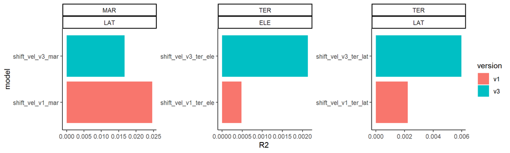

```r
ggplot(ols, aes(y = model, x = R2, fill = version))+
  geom_col()+
  theme_classic() +
  facet_wrap(ECO~Type, scales = "free")
```

In general, I believe that velocities at the landscape scale are not helpful to explain observed range shifts. We might need to work better metrics, perhaps using sdms to apply weights on landscape scale velocity based on suitability. This way, we have a species level, rather than landscape level velocity.